# Einführung in die Datenanalyse mit R

Jan-Philipp Kolb

9 Februar 2016

# Warum R nutzen?

## Gründe für die Nutzung von R

- Als Weg kreativ zu sein …
- Graphiken, Graphiken, Graphiken
- In Kombination mit anderen Programmen nutzbar
- Zur Verbindung von Datenstrukturen
- Zum Automatisieren
- Um die Intelligenz anderer Leute zu nutzen ;-)
- …

## Gründe

- R ist [frei verfügbar](http://www.inside-r.org/why-use-r). Es kann umsonst [runtergeladen](http://mirrors.softliste.de/cran/) werden.
- R ist eine Skriptsprache
- Gute Möglichkeiten für die [Visualisierung](http://research.stowers-institute.org/efg/R/) ([Link](http://www.sr.bham.ac.uk/~ajrs/R/r-gallery.html) )
- R wird immer [populärer](https://twitter.com/josiahjdavis/status/559778930476220418)

## Übersicht - warum R

[figure not shown]

## R Nutzer rund um die Welt

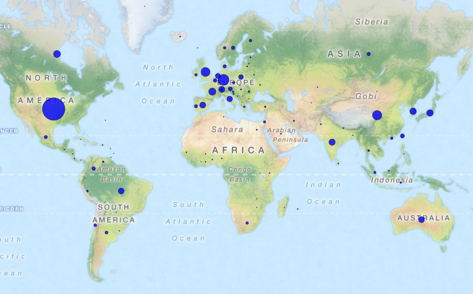

## Wo sind die aktivsten Nutzer?

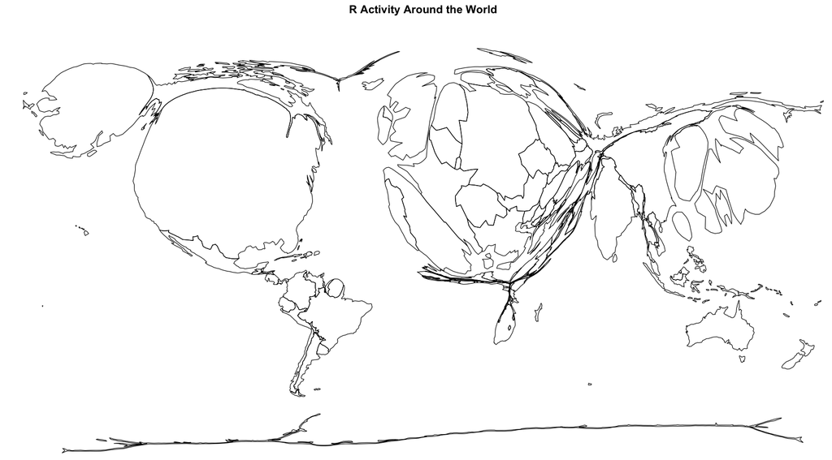

## R für SPSS Nutzer

```r
library("Rcmdr")
```

Bob Munich - [R for SPSS and SAS Users](https://science.nature.nps.gov/im/datamgmt/statistics/r/documents/r_for_sas_spss_users.pdf)

## Links

- [Vergleich python und R](http://www.dataschool.io/python-or-r-for-data-science/)
- [Warum man R für Data Science lernen sollte](http://www.r-bloggers.com/why-you-should-learn-r-first-for-data-science/)
- [R Technologie des Jahres](http://www.r-bloggers.com/rstudio-infoworld-2015-technology-of-the-year-award-recipient/)
- [Why R is Good for Business](http://www.fastcolabs.com/3030063/why-the-r-programming-language-is-good-for-business)
- [Warum R auf r-bloggers](http://www.r-bloggers.com/why-use-r/)
- [Intro R](http://www.ats.ucla.edu/stat/r/seminars/intro.htm)
- [Intro R II](http://www.ats.ucla.edu/stat/r/sk/)

## Probleme mit Excel

Weil andere Programme große Fehler haben:

- [Excel bug](http://blog.revolutionanalytics.com/2013/02/did-an-excel-error-bring-down-the-london-whale.html)
- [Datum in Excel](https://coffeehouse.dataone.org/2014/04/09/abandon-all-hope-ye-who-enter-dates-in-excel/)
- [Probleme mit Excel](http://www.biomedcentral.com/1471-2105/5/80)

# Dein Freund das Graphical User Interface (GUI)

## Anzahl der Fragen in Hilfeforen zu R

[figure not shown]

[Source](http://www.r-bloggers.com/has-r-help-gotten-meaner-over-time-and-what-does-mancur-olson-have-to-say-about-it/)

## Open Source Programm R

- R ist eine freie, nicht-kommerzielle Implementierung der Programmiersprache S (von AT&T Bell Laboratories entwickelt)
- Freie Beteiligung - modularer Aufbau (immer mehr Erweiterungspakete)
- Der Download ist auf dieser Seite möglich:

www.r-project.org

## Grpahisches User Interface

Aber die meisten Menschen nutzen einen Editor oder ein graphical user interface (GUI).

Aus den folgenden Gründen:

- Syntax highlighting
- Auto-Vervollständigung
- Bessere Übersicht über Graphiken, Bibliotheken

## Verschiedene GUIs

- [Gedit](https://projects.gnome.org/gedit/) mit R-spezifischen Add-ons für Linux
- [Emacs](http://www.gnu.org/software/emacs/)
- [TinnR](http://www.sciviews.org/Tinn-R/)
- Ich nutze [Rstudio!](https://www.rstudio.com/)

[figure not shown]

## Download der Unterlagen

Auf github sind alle Unterlagen für diesen Kurs zu finden.

[Wie nutzt man github?](https://guides.github.com/activities/hello-world/)

## Rstudio

Sechs [Gründe](http://www.r-bloggers.com/top-6-reasons-you-need-to-be-using-rstudio/) Rstudio zu nutzen.

Wie man Rstudio [nutzen kann.](https://support.rstudio.com/hc/en-us/sections/200107586-Using-RStudio)

# Grundlagen in R

## R ist eine Objekt-orientierte Sprache

Vektoren und Zuweisungen

- R ist eine Objekt-orientierte Sprache
- <- ist der Zuweisungsoperator

```r
b <- c(1,2) # erzeugt ein Objekt mit den Zahlen 1 und 2
```

- Eine Funktion kann auf dieses Objekt angewendet werden:

```r
mean(b) # berechnet den Mittelwert
```

```
## [1] 1.5
```

Mit den folgenden Funktionen können wir etwas über die Eigenschaften des Objekts lernen:

```r
length(b) # b hat die Länge 2
```

```
## [1] 2
```

## Objektstruktur

```r
str(b) # b ist ein numerischer Vektor
```

```
##  num [1:2] 1 2
```

## Funktionen im base-Paket

| Funktion | Bedeutung | Beispiel |
| --- | --- | --- |
| length() | Länge | length(b) |
| max() | Maximum | max(b) |
| min() | Minimum | min(b) |
| sd() | Standardabweichung | sd(b) |
| var() | Varianz | var(b) |
| mean() | Mittelwert | mean(b) |
| median() | Median | median(b) |

Diese Funktionen brauchen nur ein Argument.

Andere Funktionen brauchen mehr:

| Argument | Bedeutung | Beispiel |
| --- | --- | --- |
| quantile() | 90 % Quantile | quantile(b,.9) |
| sample() | Stichprobe ziehen | sample(b,1) |

## Funktionen mit einem Argument

```r
max(b)
```

```
## [1] 2
```

```r
min(b)
```

```
## [1] 1
```

```r
sd(b)
```

```
## [1] 0.7071068
```

```r
var(b)
```

```
## [1] 0.5
```

```r
mean(b)
```

```
## [1] 1.5
```

```r
median(b)
```

```
## [1] 1.5
```

## Funktionen mit mehr Argumenten

```r
quantile(b,.9)
```

```
## 90%
## 1.9
```

```r
sample(b,1)
```

```
## [1] 1
```

## Übersicht Befehle

Eine einführende Übersicht findet man [hier](http://cran.r-project.org/doc/manuals/R-intro.html)

# Datentypen

## Verschiedene Datentypen

| Datentyp | Beschreibung | Beispiel |
| --- | --- | --- |
| numeric | ganze und reele Zahlen | 5, 3.462 |
| logical | logische Werte | FALSE, TRUE |
| character | Buchstaben und Zeichenfolgen | “Hallo” |

Quelle: [R. Münnich und M. Knobelspieß](https://www.uni-trier.de/fileadmin/fb4/prof/VWL/FIN/Oekonometrie/PC-UEbung/Einfuehrung_in_R.pdf) (2007): Einführung in das statistische Programmpaket R

## Verschiedene Datentypen

```r
b <- c(1,2) # numeric
log <- c(T,F) # logical
char <-c("A","b") # character
fac <- as.factor(c(1,2)) # factor
```

## Indizieren

Indizieren eines Vektors:

```r
A1 <- c(1,2,3,4)
A1
```

```
## [1] 1 2 3 4
```

```r
A1[1]
```

```
## [1] 1
```

```r
A1[4]
```

```
## [1] 4
```

```r
A1[1:3]
```

```
## [1] 1 2 3
```

```r
A1[-4]
```

```
## [1] 1 2 3
```

## data.frames

Beispieldaten generieren:

```r
AGE <- c(20,35,48,12)
SEX <- c("m","w","w","m")
```

Diese beiden Vektoren zu einem data.frame verbinden:

```r
Daten <- data.frame(Alter=AGE,Geschlecht=SEX)
```

Anzahl der Zeilen/Spalten herausfinden

```r
nrow(Daten) # Zeilen
```

```
## [1] 4
```

```r
ncol(Daten) # Spalten
```

```
## [1] 2
```

## Indizieren

Indizieren eines dataframe:

```r
AA <- 4:1
A2 <- cbind(A1,AA)
A2[1,1]
```

```
## A1
##  1
```

```r
A2[2,]
```

```
## A1 AA
##  2  3
```

```r
A2[,1]
```

```
## [1] 1 2 3 4
```

```r
A2[,1:2]
```

```
##      A1 AA
## [1,]  1  4
## [2,]  2  3
## [3,]  3  2
## [4,]  4  1
```

## Matrizen und Arrays

- In Matrizen und Arrays stehen meist nur numerische Werte.
- Dadurch wird beispielsweise Matrix Multiplikation möglich.
- Anders als beim data.frame sind mehr als zwei Dimensionen möglich.

```r
A <- matrix(seq(1,100), nrow = 4)
dim(A)
```

```
## [1]  4 25
```

## Indizieren eines array

```r
A3 <- array(1:8,c(2,2,2))
A3
```

```
## , , 1
##
##      [,1] [,2]
## [1,]    1    3
## [2,]    2    4
##
## , , 2
##
##      [,1] [,2]
## [1,]    5    7
## [2,]    6    8
```

```r
A3[,,2]
```

```
##      [,1] [,2]
## [1,]    5    7
## [2,]    6    8
```

## Listen

- Eine Liste in R entspricht einem geschachtelten Array in anderen Programmiersprachen
- Listen können alles enthalten
- Listen können geschachtelt sein
- Listen sollte man sehr bedacht verwenden

## Indizieren einer Liste

```r
A4 <- list(A1,1)
A4
```

```
## [[1]]
## [1] 1 2 3 4
##
## [[2]]
## [1] 1
```

```r
A4[[2]]
```

```
## [1] 1
```

## Logische Operatoren

```r
# Ist 1 größer als 2?
1>2
```

```
## [1] FALSE
```

```r
1<2
```

```
## [1] TRUE
```

```r
1==2
```

```
## [1] FALSE
```

Diese Operatoren eignen sich gut um Datensätze einzuschränken

```r
Daten
```

```
##   Alter Geschlecht
## 1    20          m
## 2    35          w
## 3    48          w
## 4    12          m
```

```r
Daten[AGE>20,]
```

```
##   Alter Geschlecht
## 2    35          w
## 3    48          w
```

```r
Daten[SEX=="w",]
```

```
##   Alter Geschlecht
## 2    35          w
## 3    48          w
```

```r
# gleiches Ergebnis:
Daten[SEX!="m",]
```

```
##   Alter Geschlecht
## 2    35          w
## 3    48          w
```

```r
# Ergebnis in ein Objekt speichern
subDat <- Daten[AGE>20,]
```

```r
# mehrere Bedingeungen können mit
# & verknüpft werden:
Daten[AGE>18 & SEX=="w",]
```

```
##   Alter Geschlecht
## 2    35          w
## 3    48          w
```

## Sequenzen

```r
# Sequenz von 1 bis 10
1:10
```

```
##  [1]  1  2  3  4  5  6  7  8  9 10
```

```r
Daten[1:3,]
```

```
##   Alter Geschlecht
## 1    20          m
## 2    35          w
## 3    48          w
```

## Weitere Sequenzen

```r
seq(-2,8,by=1.5)
```

```
## [1] -2.0 -0.5  1.0  2.5  4.0  5.5  7.0
```

```r
a<-seq(3,12,length=12)

b<- seq(to=5,length=12,by=0.2)

d <-1:10
d<- seq(1,10,1)
d <- seq(length=10,from=1,by=1)

# wiederhole 1 10 mal
rep(1,10)
```

```
##  [1] 1 1 1 1 1 1 1 1 1 1
```

```r
rep("A",10)
```

```
##  [1] "A" "A" "A" "A" "A" "A" "A" "A" "A" "A"
```

## Die Funktion paste

```r
?paste
```

```r
paste(1:4)
```

```
## [1] "1" "2" "3" "4"
```

```r
paste("A", 1:6, sep = "")
```

```
## [1] "A1" "A2" "A3" "A4" "A5" "A6"
```

# Wie bekommt man Hilfe?

- [Um generell Hilfe zu bekommen:](http://itfeature.com/tag/how-to-get-help-in-r)

```r
help.start()
```

- Online Dokumentation für die meisten Funktionen:

```r
help(name)
```

- Nutze ? um Hilfe zu bekommen.

```r
?mean
```

- example(lm) gibt ein Beispiel für die lineare Regression

```r
example(lm)
```

## Nutzung Suchmaschinen

- Ich nutze meistens google
- Tippe:

R-project + Was ich schon immer wissen wollte

- Das funktioniert natürlich mit jeder Suchmaschine!

## Stackoverflow

- [Stackoverflow](http://stackoverflow.com/)
- Für Fragen zum Programmieren
- Ist nicht auf R fokussiert
- Sehr detailierte Diskussionen

[Zurück zur Gliederung.](https://github.com/Japhilko/IntroR/blob/master/2016/README.md)

# Modularer Aufbau

- Viele Funktionen sind im Basis-R enthalten
- Viele spezifische Funktionen sind in zusätzlichen Bibliotheken integriert
- R kann modular erweitert werden durch sog. packages bzw. libraries
- Auf CRAN werden die wichtigsten packages gehostet (im Moment 4567)
- Weitergehende Pakete finden sich z.B. bei bioconductor

```r
install.packages("lme4")

library(lme4)
```

## Übersicht viele nützliche Pakete:

Luhmann - [Verwendete Pakete](http://www.beltz.de/fileadmin/beltz/downloads/OnlinematerialienPVU/28090_Luhmann/Verwendete%20Pakete.pdf)

Pakete - deskriptive Datenanalyse

Die wichtigsten Pakete zur Visualisierung mit R:

- [ggplot](http://ggplot2.org/)
- [lattice](http://lattice.r-forge.r-project.org/Vignettes/src/lattice-intro/lattice-intro.pdf)
- [Visualisierung kategorialer Daten](http://www.statmethods.net/advgraphs/mosaic.html)
- [Interaktive Visualisierungen](http://cran.r-project.org/web/packages/googleVis/vignettes/googleVis_examples.html)
- [plotrix](http://www.inside-r.org/packages/cran/plotrix/docs/draw.circle)
- [Farbpaletten in R](http://cran.r-project.org/web/packages/colorspace/vignettes/hcl-colors.pdf)

# Pakete Regression

- [R-Paket MASS](http://cran.r-project.org/web/packages/MASS/MASS.pdf)
- [Autoregressive Modelle (Zeitreihen)](http://cran.r-project.org/web/packages/tsDyn/vignettes/tsDyn.pdf)
- [Robuste Regressionen](http://robustbase.r-forge.r-project.org/)
- [Nichtparametrische Regression](http://journal.r-project.org/archive/2012-2/RJournal_2012-2_Nie+S~Racine.pdf)
- [Lasso Verfahren](http://web.stanford.edu/~hastie/glmnet/glmnet_alpha.html)

## Big Data

- [Task View - High Performance Computing](http://cran.r-project.org/web/views/HighPerformanceComputing.html)

Weitere interessante Pakete

Paket für den Import/Export - [foreign](http://cran.r-project.org/web/packages/foreign/foreign.pdf)

- [Pakete für Survey Sampling](http://iase-web.org/documents/papers/icots8/ICOTS8_4J1_TILLE.pdf)
- Paket - Latex und R (xtable) ([xtable Galerie](http://cran.r-project.org/web/packages/xtable/vignettes/xtableGallery.pdf))
- [Paket zur Erzeugung von Dummies](http://cran.r-project.org/web/packages/dummies/dummies.pdf)
- [Multivariate Normalverteilung](http://cran.r-project.org/web/packages/mvtnorm/index.html)
- [Paket für Karten](http://www.r-bloggers.com/tag/maptools/)

# Datenquellen

## Datenzugang

- Public-Use-File (PUF) Datei zur öffentlichen Nutzung - meist stark anonymisierte Daten (Beispiele: FDZ, Statistik Portal, Meine Region )
- Scientific-Use-File (SUF) - Datei zur wissenschaftlichen Nutzung - anonymisierte Daten, die zu wissenschaftlichen Zwecken und zur Sekundäranalyse genutzt werden können.
- On-Site-Nutzung - Arbeitsplätze für Gastwissenschaftler - Kontrollierte Datenfernverarbeitung

## Datenquellen

- Auf dem Portal [datahub.io](http://datahub.io/) sind sehr viele Beispieldatensätze in verschiedenen Formaten abrufbar.
- Weitere Portale: [OpenGov](http://ropengov.github.io/projects/), [okfn](http://data.okfn.org/), [enigma](https://app.enigma.io/table/org.worldbank.hnp.data), Amazon Web Services ([AWS](http://aws.amazon.com/de/public-data-sets/))
- Umweltdaten ([National climatic data center](http://www.ncdc.noaa.gov/ibtracs/index.php?name=ibtracs-data))
- [FAO Datenbank](http://cran.r-project.org/web/packages/FAOSTAT/index.html)

```r
library("FAOSTAT")
```

- Public Use File für Soziales in den USA [Social security administration](http://www.ssa.gov/policy/docs/data/index.html)
- National health and nutrition examination survey

```r
library(survey)
data(nhanes)
```

## Das R-Paket datasets

```r
library(datasets)
```

Beispiel Erdbeben Datensatz:

```r
head(quakes)
```

## Datensatz zum US Zensus

```r
library(UScensus2010)
```

## Weltbank Daten

[`WDI`](https://cran.r-project.org/web/packages/WDI/index.html) - World Development Indicators (World Bank) - [Einführung in das Paket](https://github.com/vincentarelbundock/WDI)

```r
library(WDI)
```

```r
WDIsearch('gdp')[1:10,]
```

## Nutzung von WDI Daten

```r
dat <-  WDI(indicator='NY.GDP.PCAP.KD', country=c('MX','CA','US'), start=1960, end=2012)
head(dat)
```

## OpenStreetMap

> OpenStreetMap (OSM) ist ein kollaboratives Projekt um eine editierbare Weltkarte zu erzeugen.

[Wikipedia - OpenStreetMap](https://en.wikipedia.org/wiki/OpenStreetMap)

## Download von OpenStreetMap Daten

```r
library(osmar)
api <- osmsource_api()
library(ggmap)
```

```r
cityC <- geocode("Berlin",source="google")
bb <- center_bbox(cityC$lon,cityC$lat,1000, 1000)
uaBerlin <- get_osm(bb, source = api)
```

- Ausschnitte von OpenStreetMap für einzelne Städte ([metro extracts](https://mapzen.com/data/metro-extracts/))
- Liste möglicher Datenquellen für räumliche Analysen ([weltweit](http://wiki.openstreetmap.org/wiki/Potential_Datasources), [Deutschland](http://wiki.openstreetmap.org/wiki/DE:Potential_Datasources) )
- SALB - Administrative Grenzen
- Kartendaten ([openaprs](http://www.openaprs.net/))

## TwittR

```r
library(twitteR)
library(streamR)
```

http://www.r-bloggers.com/mapping-the-world-with-tweets-including-a-gif-without-cats-and-a-shiny-app/

## worldHires Daten

```r
library(mapdata)
data(worldHiresMapEnv)
map('worldHires', col=1:10)
```

## Historische Daten

- [Historischer Geocoder](http://www.azavea.com/blogs/newsletter/v2i3/azavea-research-historic-geocoder/)
- [Paket HistData](http://www.inside-r.org/packages/cran/HistData)

```r
library(HistData)
data(Arbuthnot)
```

## GDELT Daten

- [GDELT](http://www.gdeltproject.org/)
- Nutzung von GDELT Daten ([Beispiel 1](http://quantifyingmemory.blogspot.de/2013/04/mapping-gdelt-data-in-r-and-some.html), [Beispiel 2](http://www.kalevleetaru.com/))

```r
library(GDELTtools)
test.filter <- list(ActionGeo_ADM1Code=c("NI", "US"), ActionGeo_CountryCode="US")
test.results <- GetGDELT(start.date="1979-01-01", end.date="1979-12-31",
                         filter=test.filter)
```

## Andere Datenquellen

- [Die US Flughäfen und Fluglinien](http://www.sasanalysis.com/2013/06/the-us-airports-with-most-flight-routes.html)
- Mehr Daten [hier](http://openflights.org/data.html)

```r
link1 <- "http://openflights.svn.sourceforge.net/viewvc/openflights/
openflights/data/airports.dat"
airport <- read.csv(link1, header = F)

link2 <- "http://openflights.svn.sourceforge.net/viewvc/openflights/
openflights/data/routes.dat"
route <- read.csv(link2, header = F)
```

- Hafen Daten ([Natural earth data](http://www.naturalearthdata.com/downloads/10m-cultural-vectors/))
- [Minimalistische Karten](http://www.r-bloggers.com/minimalist-maps/)
- [Census results - Germany](https://ergebnisse.zensus2011.de/)
- [Census results - Britain](http://www.r-bloggers.com/2011-census-open-atlas-project/) and [boundaries](http://www.ons.gov.uk/ons/guide-method/census/2011/census-data/2011-census-prospectus/new-developments-for-2011-census-results/2011-census-geography/2011-census-geography-prospectus/index.html)
- [Data on airports](http://openflights.org/data.html) and an [example](http://www.milanor.net/blog/?p=594) on the usage in R
- [ADFC/opengeodb](http://www.fa-technik.adfc.de/code/opengeodb/)

```r
link <- "http://www.fa-technik.adfc.de/code/opengeodb/DE9.tab"
info <- read.csv(link,sep="\t",header=F)
```

## Weitere Quellen

- [ICEDS European Data Server](http://geocommons.com/overlays/96341)
- [Mobilfunkdaten](http://opencellid.org/), [CO2 Emmissionen](http://databank.worldbank.org/data/reports.aspx?source=2&country=DEU&series=&period=)
- Daten für New York ([Daten](https://data.cityofnewyork.us/), [Beispiel](https://data.cityofnewyork.us/City-Government/Parking-Violations-Issued-Fiscal-Year-2014-August-/jt7v-77mi)

# Datenimport

## Dateiformate in R

- Von R werden quelloffene, nicht-proprietäre Formate bevorzugt - Es können aber auch Formate von anderen Statistik Software Paketen eingelesen werden - R-user speichern Objekte gerne in sog. Workspaces ab - Auch hier jedoch gilt: (fast) alles andere ist möglich

## Formate - base package

- R unterstützt von Haus aus schon einige wichtige Formate:

  ```
          -  CSV (Comma Separated Values): `read.csv()`
          -  FWF (Fixed With Format): `read.fwf()`
          -  Tab-getrennte Werte: `read.delim()`
  ```

## Der Arbeitsspeicher

So findet man heraus, in welchem Verzeichnis man sich gerade befindet

```r
getwd()
```

So kann man das Arbeitsverzeichnis ändern:

Man erzeugt ein Objekt in dem man den Pfad abspeichert:

```r
main.path <- "C:/" # Beispiel für Windows
main.path <- "/users/Name/" # Beispiel für Mac
main.path <- "/home/user/" # Beispiel für Linux
```

Und ändert dann den Pfad mit setwd()

```r
setwd(main.path)
```

Bei Windows ist es wichtig Slashs anstelle von Backslashs zu verwenden.

## Import von Excel-Daten

- `library(foreign)` ist für den Import von fremden Datenformaten nötig
- Wenn Excel-Daten vorliegen - als .csv abspeichern
- Dann kann `read.csv()` genutzt werden um die Daten einzulesen.
- Bei Deutschen Daten kann es sein, dass man `read.csv2()` wegen der Komma-Separierung braucht.

```r
library(foreign)
?read.csv
?read.csv2
```

## CSV Dateien einlesen

Zunächst muss das Arbeitsverzeichnis gesetzt werden, in dem sich die Daten befinden:

```r
Dat <- read.csv("schuldaten_export.csv")
```

Wenn es sich um Deutsche Daten handelt:

```r
Dat <- read.csv2("schuldaten_export.csv")
```

## SPSS Dateien einlesen

Dateien können auch direkt aus dem Internet geladen werden:

```r
link<- "http://www.statistik.at/web_de/static/
mz_2013_sds_-_datensatz_080469.sav"

?read.spss
Dat <- read.spss(link,to.data.frame=T)
```

## stata Dateien einlesen

```r
MZ02 <- read.dta("MZ02.dta")
```

- Einführung in Import mit R ([is.R](http://is-r.tumblr.com/post/37181850668/reading-writing-stata-dta-files-with-foreign))

## Datenmanagement ähnlich wie in SPSS oder Stata

```r
install.packages("Rz")
library(Rz)
```

# Datenexport

## R’s Exportformate

- In R werden offene Dateiformate bevorzugt
- Als Äquivalenz zu den `read.X()` Funktionen stehen viele `write.X()` Funktionen zur Verfügung
- Das eigene Format von R sind sog. Workspaces (`.RData`)

## Beispieldatensatz erzeugen

```r
A <- c(1,2,3,4)
B <- c("A","B","C","D")

mydata <- data.frame(A,B)
```

## Überblick Daten Import/Export

```r
save(mydata, file="mydata.RData")
```

## Daten in Excel Format abspeichern

```r
write.csv(mydata,file="mydata.csv")
```

```r
library(xlsx)
write.xlsx(mydata,file="mydata.xlsx")
```

## Daten in stata Format abspeichern

```r
library(foreign)
write.dta(mydata,file="mydata.dta")
```

## Links Export

- [Quick R](http://www.statmethods.net/input/exportingdata.html) für das Exportieren von Daten:
- Hilfe zum Export auf dem [cran Server](http://cran.r-project.org/doc/manuals/r-release/R-data.pdf)

## Streuungsmaße

Im base Package sind die wichtigsten Streuungsmaße enthalten:

- Varianz: `var()`
- Standardabweichung: `sd()`
- Minimum und Maximum: `min()` und `max()`
- Range: `range()`

```r
ab <- rnorm(100)

var(ab)
```

```
## [1] 0.8606866
```

```r
sd(ab)
```

```
## [1] 0.927732
```

```r
range(ab)
```

```
## [1] -2.315260  2.511663
```

## Extremwerte

```r
min(ab)
```

```
## [1] -2.31526
```

```r
max(ab)
```

```
## [1] 2.511663
```

## Fehlende Werte

- Sind `NA`s vorhanden muss dies der Funktion mitgeteilt werden

```r
ab[10] <- NA

var(ab)
```

```
## [1] NA
```

Bei fehlenden Werten muss ein weiteres Argument mitgegeben werden:

```r
var(ab,na.rm=T)
```

```
## [1] 0.8689515
```

## Häufigkeiten und gruppierte Kennwerte

- Eine Auszählung der Häufigkeiten der Merkmale einer Variable liefert `table()`
- Mit `table()` sind auch Kreuztabellierungen möglich indem zwei Variablen durch Komma getrennt werden: `table(x,y)` liefert Häufigkeiten von `y` für gegebene Ausprägungen von `x`

```r
x <- sample(1:10,100,replace=T)

table(x)
```

```
## x
##  1  2  3  4  5  6  7  8  9 10
## 13 18 11  7  9 12  3 10  9  8
```

## Tabellieren - weiteres Beispiel

```r
musician <- sample(c("yes","no"),100,replace=T)
```

```r
?table
```

```r
table(x)
```

```
## x
##  1  2  3  4  5  6  7  8  9 10
## 13 18 11  7  9 12  3 10  9  8
```

```r
table(x,musician)
```

```
##     musician
## x    no yes
##   1   6   7
##   2  10   8
##   3   7   4
##   4   2   5
##   5   5   4
##   6   7   5
##   7   1   2
##   8   6   4
##   9   4   5
##   10  0   8
```

```r
data(esoph)
table(esoph$agegp)
```

```
##
## 25-34 35-44 45-54 55-64 65-74   75+
##    15    15    16    16    15    11
```

## Häufigkeitstabellen

- `prop.table()` liefert die relativen Häufigkeiten
- Wird die Funktion außerhalb einer `table()` Funktion geschrieben erhält man die relativen Häufigkeiten bezogen auf alle Zellen

Die Funktion prop.table()

```r
table(esoph$agegp,esoph$alcgp)
?prop.table
prop.table(table(esoph$agegp,
esoph$alcgp),1)
```

## Die aggregate Funktion

- Mit der `aggregate()` Funktion können Kennwerte für Untergruppen erstellt werden
- `aggregate(x,by,FUN)` müssen mindestens drei Argumente übergeben werden:

```r
aggregate(state.x77,by=list(state.region),mean)
```

```
##         Group.1 Population   Income Illiteracy Life Exp    Murder  HS Grad
## 1     Northeast   5495.111 4570.222   1.000000 71.26444  4.722222 53.96667
## 2         South   4208.125 4011.938   1.737500 69.70625 10.581250 44.34375
## 3 North Central   4803.000 4611.083   0.700000 71.76667  5.275000 54.51667
## 4          West   2915.308 4702.615   1.023077 71.23462  7.215385 62.00000
##      Frost      Area
## 1 132.7778  18141.00
## 2  64.6250  54605.12
## 3 138.8333  62652.00
## 4 102.1538 134463.00
```

x: ein oder mehrere Beobachtungsvektor(en) für den der Kennwert berechnet werden soll

by: eine oder mehrere bedingende Variable(n)

FUN: die Funktion welche den Kennwert berechnet (z.B. `mean` oder `sd`)

- Die Ausgabe kann mit Hilfe von `xtabs()` in eine schöne zweidimensionale Tabelle überführt werden

## Beispieldatensatz - apply Funktion

```r
ApplyDat <- cbind(1:4,runif(4),rnorm(4))
```

```r
apply(ApplyDat,1,mean)
```

```
## [1] 0.680296 1.327155 1.661083 1.798113
```

```r
apply(ApplyDat,2,mean)
```

```
## [1] 2.5000000 0.5695852 1.0303996
```

## Die Funktion apply

```r
apply(ApplyDat,1,var)
```

```
## [1] 0.1638719 0.3432279 1.4643456 3.6843819
```

```r
apply(ApplyDat,1,sd)
```

```
## [1] 0.4048109 0.5858566 1.2101015 1.9194744
```

```r
apply(ApplyDat,1,range)
```

```
##          [,1]      [,2]     [,3]      [,4]
## [1,] 0.225124 0.9300082 0.645472 0.4777365
## [2,] 1.000000 2.0000000 3.000000 4.0000000
```

```r
apply(ApplyDat,1,length)
```

```
## [1] 3 3 3 3
```

## Argumente der Funktion apply

- Für `margin=1` die Funktion `mean` auf die Reihen angewendet,
- Für `margin=2` die Funktion `mean` auf die Spalten angewendet,
- Anstatt `mean` können auch andere Funktionen wie `var`, `sd` oder `length` verwendet werden.

## Die Funktion tapply

```r
ApplyDat <- data.frame(Income=rnorm(5,1400,200),
                       Sex=sample(c(1,2),5,replace=T))
```

- Auch andere Funktionen können eingesetzt werden…. - Auch selbst programmierte Funktionen
- Im Beispiel wird die einfachste eigene Funktion angewendet.

```r
ApplyDat
```

```
##     Income Sex
## 1 1532.006   2
## 2 1516.304   1
## 3 1427.915   1
## 4 1157.995   2
## 5 1951.930   2
```

## Beispiel Funktion tapply

```r
tapply(ApplyDat$Income,ApplyDat$Sex,mean)
```

```
##        1        2
## 1472.109 1547.310
```

```r
tapply(ApplyDat$Income,
       ApplyDat$Sex,function(x)x)
```

```
## $`1`
## [1] 1516.304 1427.915
##
## $`2`
## [1] 1532.006 1157.995 1951.930
```

## Links Datenanalyse

- Benutzung von `apply`, `tapply`, etc. ([R-bloggers](http://www.r-bloggers.com/using-apply-sapply-lapply-in-r/))
- [Zurück zur Gliederung](https://github.com/Japhilko/IntroR/blob/master/2016/README.md)

# Einfache Grafiken

## Ein Plot sagt mehr als 1000 Worte

- Grafisch gestützte Datenanalyse ist toll
- Gute Plots können zu einem besseren Verständnis beitragen
- Einen Plot zu generieren geht schnell
- Einen guten Plot zu machen kann sehr lange dauern
- Mit R Plots zu generieren macht Spaß
- Mit R erstellte Plots haben hohe Qualität
- Fast jeder Plottyp wird von R unterstützt
- R kennt eine große Menge an Exportformaten für Grafiken

## Plot ist nicht gleich Plot

- Bereits das base Package bringt eine große Menge von Plot Funktionen mit
- Das lattice Packet erweitert dessen Funktionalität
- Eine weit über diese Einführung hinausgehende Übersicht findet sich in Murrell, P (2006): R Graphics.

## CRAN Task Views

- Zu einigen Themen sind alle Möglichkeiten in R zusammengestellt. ([Übersicht der Task Views](https://cran.r-project.org/web/views/))
- Task View zu Thema [Graphiken](https://cran.r-project.org/web/views/Graphics.html)

## Datensatz

```r
library(mlmRev)
data(Chem97)
```

- [lea] Local Education Authority - a factor
- [school] School identifier - a factor
- [student] Student identifier - a factor
- [score] Point score on A-level Chemistry in 1997
- [gender] Student’s gender
- [age] Age in month, centred at 222 months or 18.5 years
- [gcsescore] Average GCSE score of individual.
- [gcsecnt] Average GCSE score of individual, centered at mean.

## Histogramm

Wir erstellen ein Histogramm der Variable gcsescore:

Die Funktion hist()

```r
?hist
```

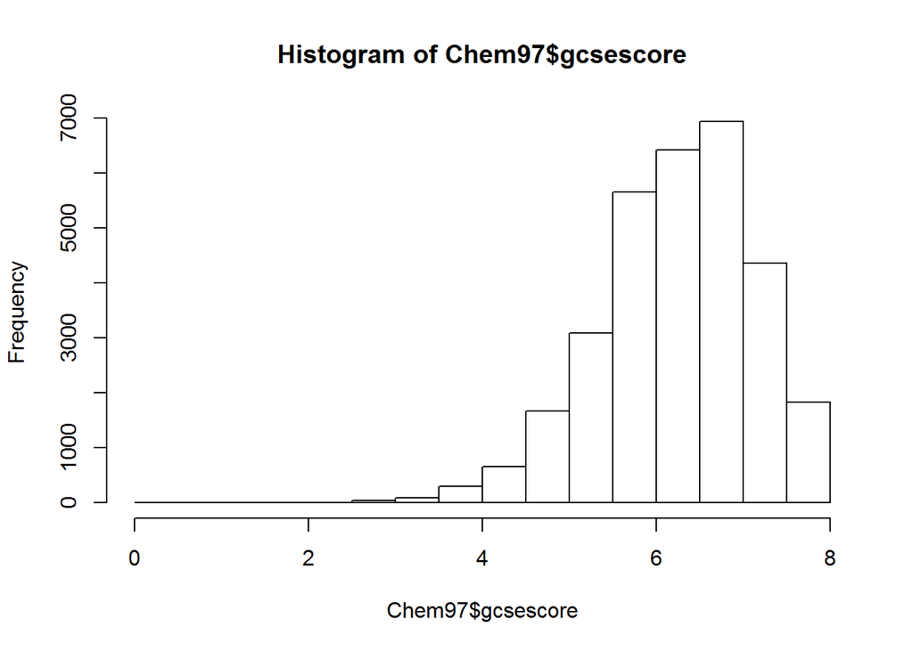

```r
# Histogramm
hist(Chem97$gcsescore)
```

## Graphik speichern

- Mit dem button Export in Rstudio kann man die Grafik speichern.
- Alternativ auch bspw. mit dem Befehl `png`

```r
png("Histogramm.png")
hist(Chem97$gcsescore)
dev.off()
```

## Histogramme

- Die Funktion `hist()` plottet ein Histogramm der Daten
- Der Funktion muss mindestens ein Beobachtungsvektor übergeben werden
- `hist()` hat noch sehr viel mehr Argumente, die alle (sinnvolle) default values haben

| Argument | Bedeutung | Beispiel |
| --- | --- | --- |
| main | Überschrift | main=“Hallo Welt” |
| xlab | x-Achsenbeschriftung | xlab=“x-Werte” |
| ylab | y-Achsenbeschriftung | ylab=“y-Werte” |
| col | Farbe | col=“blue” |

## Histogramm

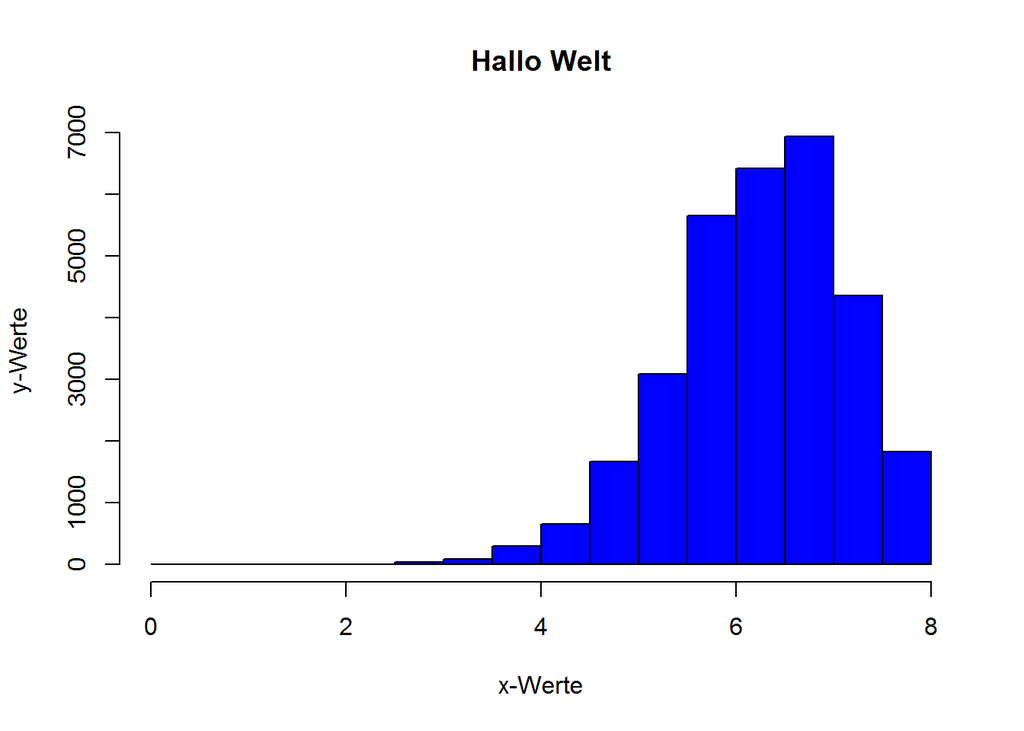

```r
hist(Chem97$gcsescore,col="blue",
     main="Hallo Welt",ylab="y-Werte",
     xlab="x-Werte")
```

Weitere Argumente:

```r
?plot
# oder
?par
```

## Barplot

- Die Funktion barplot() erzeugt aus einer Häufigkeitstabelle einen Barplot
- Ist das übergebene Tabellen-Objekt zweidimensional wird ein bedingter Barplot erstellt

```r
tabScore <- table(Chem97$score)
```

```r
barplot(tabScore)
```

## Barplots und barcharts

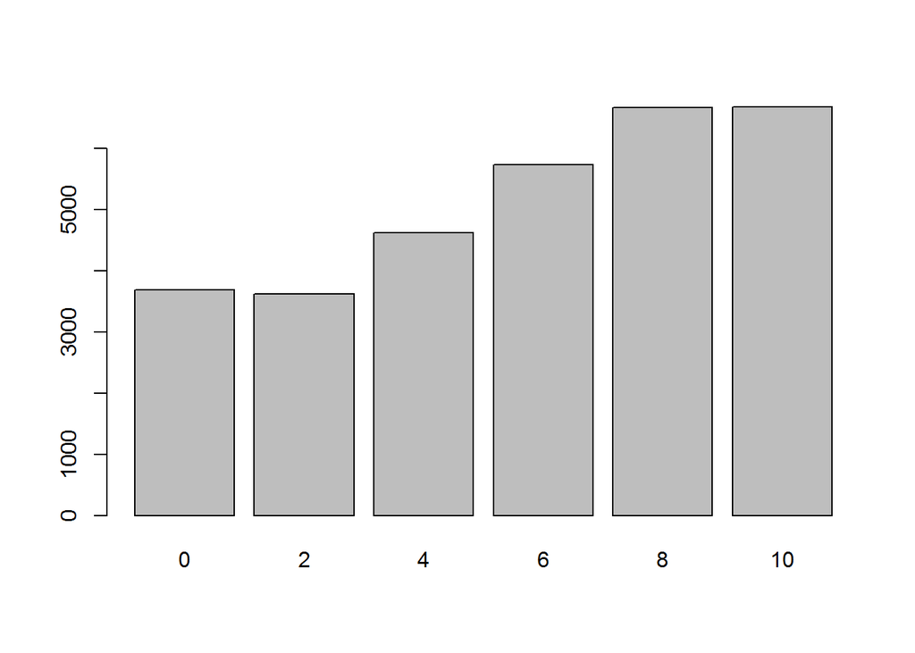

```r
barplot(tabScore)
```

## Mehr Farben:

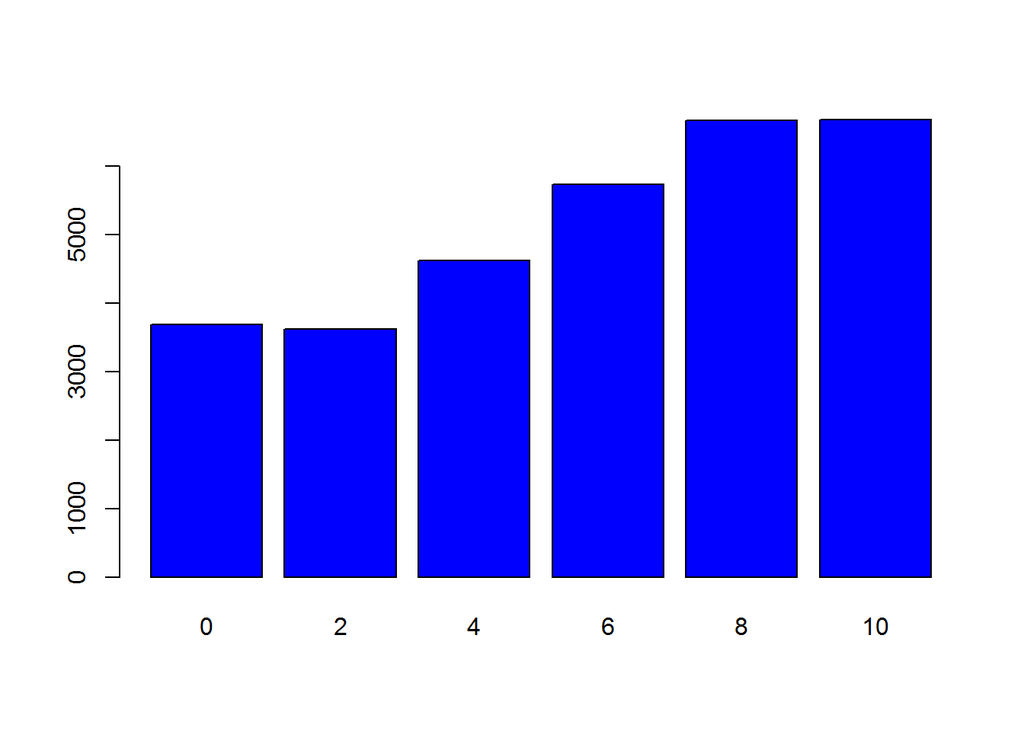

```r
barplot(tabScore,col=rgb(0,0,1))
```

## Grüne Farbe

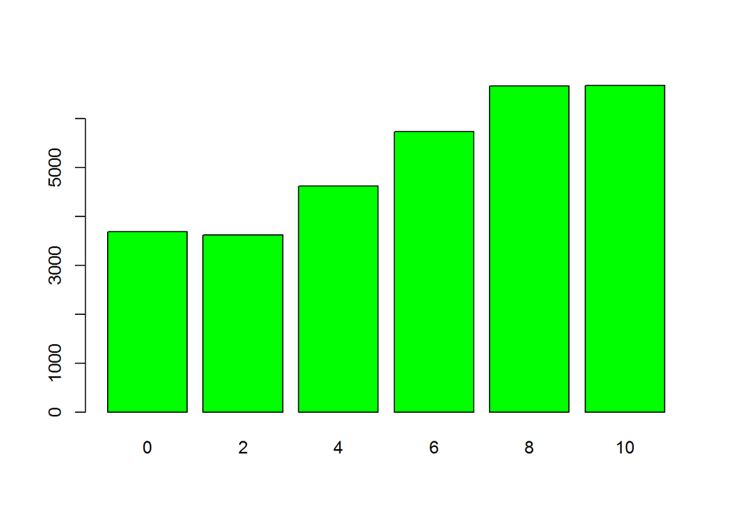

```r
barplot(tabScore,col=rgb(0,1,0))
```

## Rote Farbe

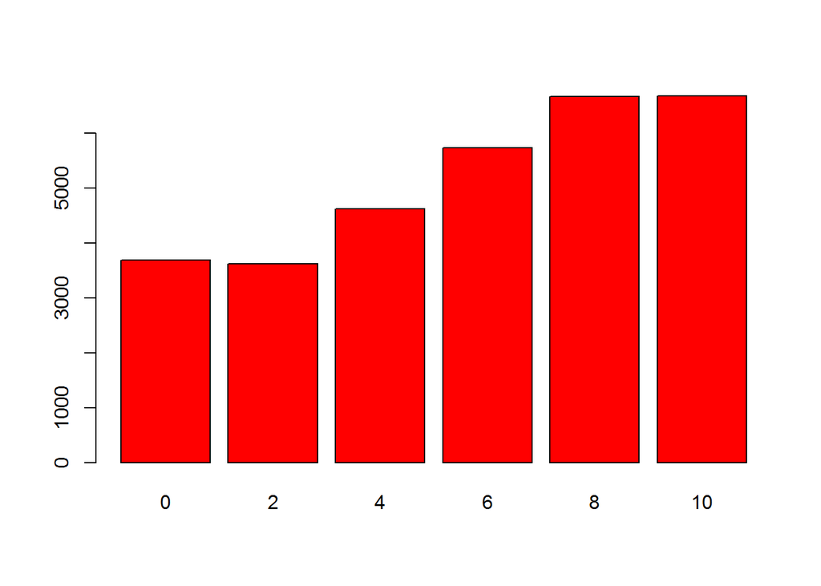

```r
barplot(tabScore,col=rgb(1,0,0))
```

## Transparent

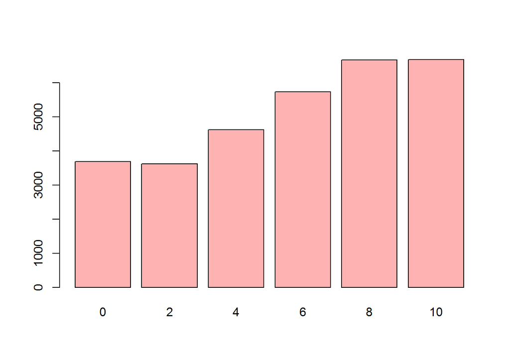

```r
barplot(tabScore,col=rgb(1,0,0,.3))
```

## Boxplot

- Einen einfachen Boxplot erstellt man mit `boxplot()`
- Auch `boxplot()` muss mindestens ein Beobachtungsvektor übergeben werden

```r
?boxplot
```

## Horizontaler Boxplot

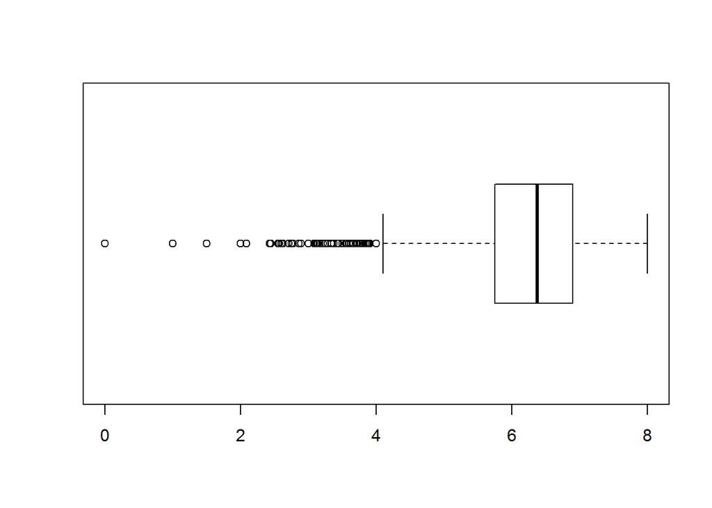

```r
boxplot(Chem97$gcsescore,
horizontal=TRUE)
```

- [Erklärung zu Boxplots](http://edoc.hu-berlin.de/dissertationen/gruenwald-andreas-2005-01-17/HTML/chapter2.html)

## Gruppierte Boxplots

- Ein sehr einfacher Weg, einen ersten Eindruck über bedingte Verteilungen zu bekommen ist über sog. Gruppierte notched Boxplots
- Dazu muss der Funktion `boxplot()` ein sog. Formel-Objekt übergeben werden
- Die bedingende Variable steht dabei auf der rechten Seite einer Tilde

## Beispiel grupierter Boxplot

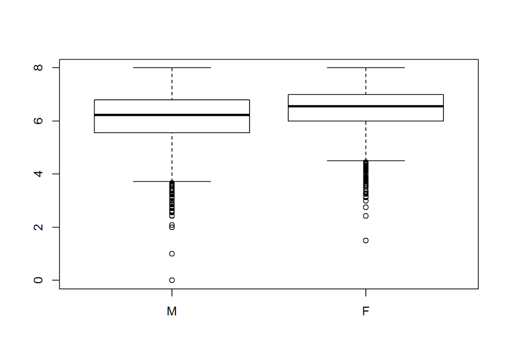

```r
boxplot(Chem97$gcsescore~Chem97$gender)
```

## Alternativen zu Boxplot

Violinplot

- Baut auf Boxplot auf
- Zusätzlich Informationen über Dichte der Daten
- Dichte wird über Kernel Methode berechnet.
- weißer Punkt - Median
- Je weiter die Ausdehnung, desto größer ist die Dichte an dieser Stelle.

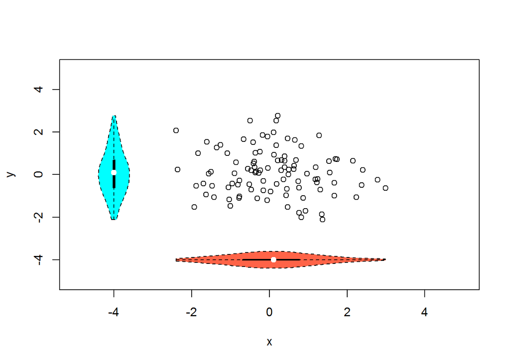

```r
library(vioplot)
x <- rnorm(100)
y <- rnorm(100)
plot(x, y, xlim=c(-5,5), ylim=c(-5,5))
vioplot(x, col="tomato", horizontal=TRUE, at=-4, add=TRUE,lty=2, rectCol="gray")
vioplot(y, col="cyan", horizontal=FALSE, at=-4, add=TRUE,lty=2)
```

## Alternativen zum Boxplot

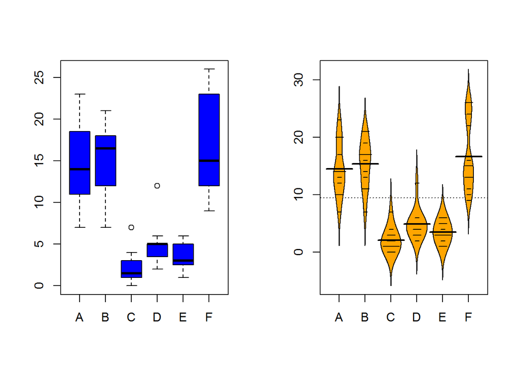

```r
library(beanplot)
par(mfrow = c(1,2))
boxplot(count~spray,data=InsectSprays,col="blue")
beanplot(count~spray,data=InsectSprays,col="orange")
```

# Grafiken für bedingte, bi- und multivariate Verteilungen

## Scatterplots

- Ein einfacher two-way scatterplot kann mit der Funktion plot() erstellt werden
- plot() muss mindestens ein x und ein y Beobachtungsvektor übergeben werden
- Um die Farbe der Plot-Symbole anzupassen gibt es die Option col (Farbe als character oder numerisch)
- Die Plot-Symbole selbst können mit pch} (plotting character) angepasst werden (character oder numerisch)
- Die Achenbeschriftungen (labels) werden mit xlab und ylab definiert

# Multidimensionale Zusammenhänge

## Edgar Anderson’s Iris Daten

```r
data(iris)
head(iris)
```

```
##   Sepal.Length Sepal.Width Petal.Length Petal.Width Species
## 1          5.1         3.5          1.4         0.2  setosa
## 2          4.9         3.0          1.4         0.2  setosa
## 3          4.7         3.2          1.3         0.2  setosa
## 4          4.6         3.1          1.5         0.2  setosa
## 5          5.0         3.6          1.4         0.2  setosa
## 6          5.4         3.9          1.7         0.4  setosa
```

petal length and width - Blütenblatt Länge und Breite

sepal length and width - Kelchblatt Länge und Breite

- [Wikipedia Artikel zum IRIS Datensatz](https://en.wikipedia.org/wiki/Iris_flower_data_set)

## Zusammenhang zwischen stetigen Variablen

```r
# Pearson Korrelationskoeffizient
cor(iris$Sepal.Length,iris$Petal.Length)
```

```
## [1] 0.8717538
```

- Korrelation zwischen Länge Kelchblatt und Blütenblatt 0,87
- Der Pearson’sche Korrelationskoeffizient ist die default methode in `cor()`.

## Zusammenhang zwischen mehreren Variablen

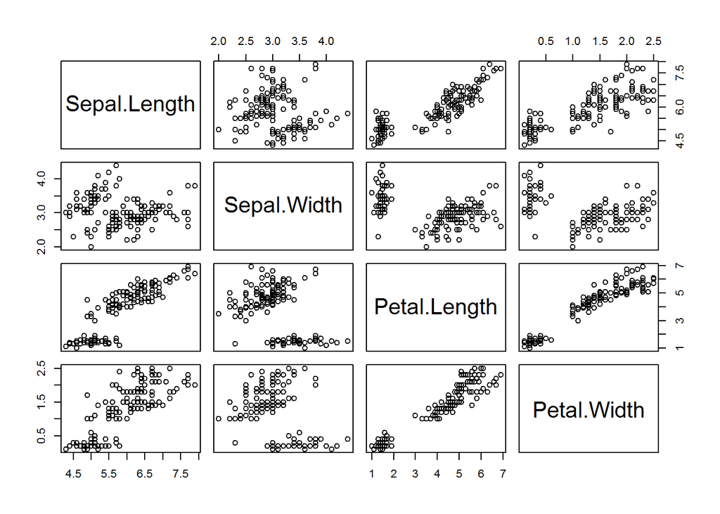

```r
pairs(iris[,1:4])
```

## Zusammenhang zwischen mehreren Variablen

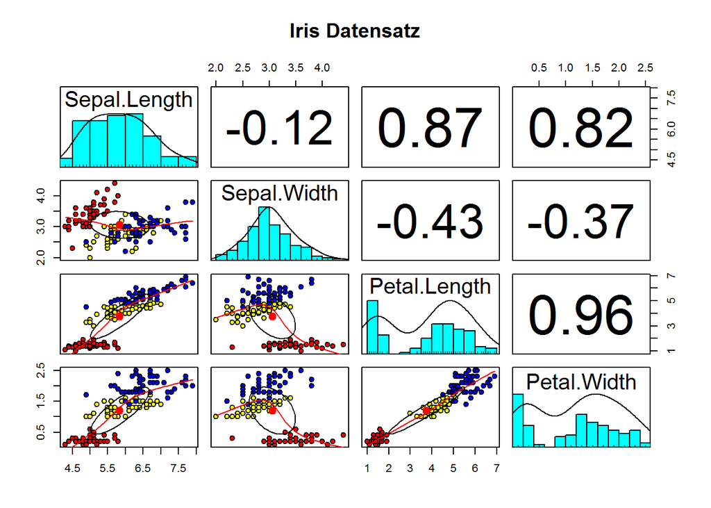

```r
library("psych")
pairs.panels(iris[1:4],bg=c("red","yellow","blue")
[iris$Species],pch=21,main="Iris Datensatz")
```

## Verschiedene Korrelationskoeffizienten

```r
# Pearson Korrelationskoeffizient
cor(iris[,1:4])
```

```
##              Sepal.Length Sepal.Width Petal.Length Petal.Width
## Sepal.Length    1.0000000  -0.1175698    0.8717538   0.8179411
## Sepal.Width    -0.1175698   1.0000000   -0.4284401  -0.3661259
## Petal.Length    0.8717538  -0.4284401    1.0000000   0.9628654
## Petal.Width     0.8179411  -0.3661259    0.9628654   1.0000000
```

```r
# Kendall's tau (Rangkorrelation)
cor(iris[,1:4], method = "kendall")
```

```
##              Sepal.Length Sepal.Width Petal.Length Petal.Width
## Sepal.Length   1.00000000 -0.07699679    0.7185159   0.6553086
## Sepal.Width   -0.07699679  1.00000000   -0.1859944  -0.1571257
## Petal.Length   0.71851593 -0.18599442    1.0000000   0.8068907
## Petal.Width    0.65530856 -0.15712566    0.8068907   1.0000000
```

```r
# Spearman's rho (Rangkorrelation)
cor(iris[,1:4], method = "spearman")
```

```
##              Sepal.Length Sepal.Width Petal.Length Petal.Width
## Sepal.Length    1.0000000  -0.1667777    0.8818981   0.8342888
## Sepal.Width    -0.1667777   1.0000000   -0.3096351  -0.2890317
## Petal.Length    0.8818981  -0.3096351    1.0000000   0.9376668
## Petal.Width     0.8342888  -0.2890317    0.9376668   1.0000000
```

## Zusammenhang zwischen kategorialen Variablen

- chisq.test() testet, ob zwei kategoriale Merkmale stochastisch unabhängig sind.
- Getestet wird gegen die Nullhypothese der Gleichverteilung

## Levelplot

```r
library("lattice")
library("AER")
```

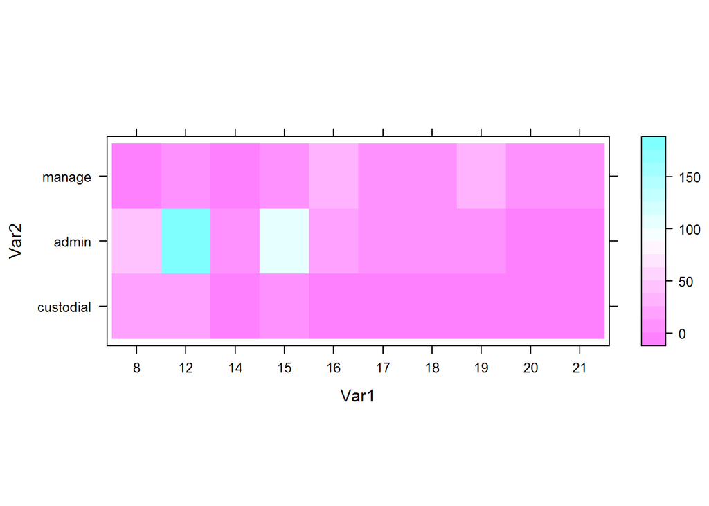

```r
data(BankWages)
levelplot(table(BankWages$education,BankWages$job))
```

## Visualisierung von Zusammenhängen zwischen kategorialen Variablen

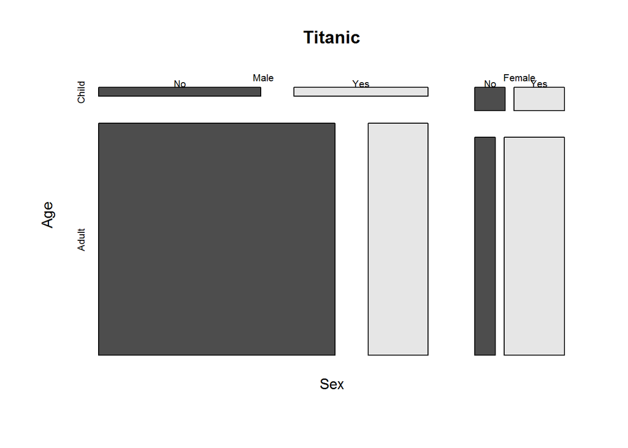

```r
mosaicplot(~ Sex + Age + Survived,
           data = Titanic, color = TRUE)
```

## Shading

Flächen werden entsprechend der Residuen eingefärbt:

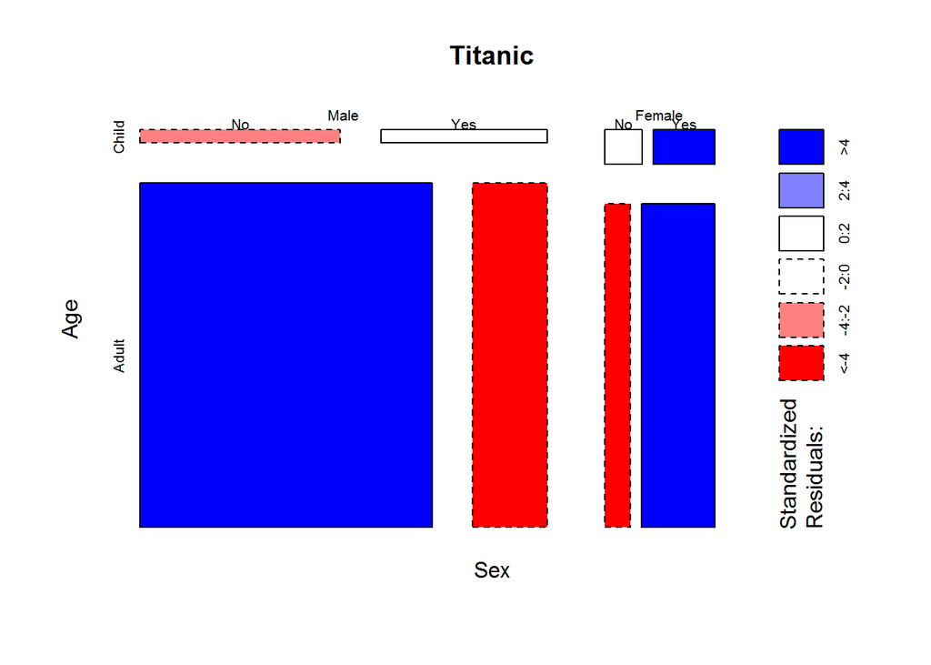

```r
mosaicplot(~ Sex + Age + Survived,
           data = Titanic, shade = TRUE)
```

## Literatur zu Zusammenhangsmaßen

- Methodensammlung mit R
- Beispiele zu Zusammenhangsmaßen
- Umsetzung in R

Sachs - [Angewandte Statistik mit R](https://books.google.de/books/about/Angewandte_Statistik.html?id=S-zXmAEACAAJ&redir_esc=y)